# 유동인구 분석

Jun

2020-02-24

**데이터 출처: [SKT Data Hub](https://www.bigdatahub.co.kr/product/list.do?menu_id=1000157)**  
**Github Code: [Jun4871 Github](https://github.com/Jun4871/R_programing/blob/master/population.Rmd)**

# Overview

이번 데이터 분석은 최근 작업했던 19년 12월 유동인구 분석의 연장선이다. 조금 더 다각도에서 바라보고 파고들어 상업적 측면에서의 새로운 인사이트를 찾아서 상업성과 유동인구를 연관지어 보는 것이 분석목표이다. 데이터는 19년 3월 ~ 19년 12월까지, 총 10개월 분량의 데이터를 다룰 것이다.

# 라이브러리 활성화

데이터 분석에 앞서 필요한 도구를 준비하는 단계로 아래 라이브러리들을 활용하였다.

```r
library(tidyverse)
library(fs)
library(lubridate)
library(gridExtra)
library(ggthemes)
library(DT)
library(ggplot2)
library(plotly)
library(mlbench)
library(formattable)
```

# 데이터 로드

지난 번 분석에서는 하나의 csv 파일을 불러왔기 때문에 loading 시 큰 어려움이 없었다. 하지만 이번에는 10개의 csv 파일을 불러와야 하기 때문에 다른 방법을 통해 데이터를 불러올 것이다.

```r
Population_19 <- "year_19"
year_19_pop <- fs::dir_ls(Population_19)

# 데이터 취합
year_19_data <- year_19_pop %>%
  map_dfr(read_csv)

# 데이터 프레임 형식으로 변환
year_19_pop_data_frame <- as.data.frame(year_19_data)
```

# 데이터 가공 및 NA 파악

이제 불러온 데이터 구조를 파악하고, 분석목적에 맞게 가공을 해줄 것이다. NA와 NULL은 없었으나, 데이터 속성변환이 필요한 것들이 보여 바꿔주었다. 첫번째, 기본적으로 서울시 내의 유동인구를 조사한 것이므로 각 행에 ’시(city)’를 포함시킬 필요가 없어 해당 컬럼을 제거했다. 이것은 타이틀 제목을 통해 보여줄 수 있는 부분이고, 포함시켜서 분석을 하는 것이 큰 의미가 없기 때문이다. 두번째, 날짜를 날짜형 데이터에 맞게 바꿔주었다. 원래 숫자형으로 되어있었는데, 이는 다닥다닥 붙어 있어 가독성이 떨어지고, 월(Month)이나 일(Date)를 추출할 때, 숫자형이라면 인식하는데 어려움이 있을 것 같았다. 세번째, 컬럼명을 영문화 시켰다. R 환경에서는 한글에 대한 지원도가 떨어지는 편이고, 기본 함수들도 모두 영문이므로 통일성과 호환성을 고려해 영문화했다. 네번째, 범주형 데이터들에 한하여, 펙터화 시키고 레벨을 지정해주었다.

```r
year_19_pop_data_frame2 <- year_19_pop_data_frame

year_19_pop_data_frame <- year_19_pop_data_frame2

head(str(year_19_pop_data_frame, 50))
```

```
## 'data.frame':    2192700 obs. of  7 variables:
##  $ 일자            : num  20190301 20190301 20190301 20190301 20190301 ...
##  $ 시간(1시간단위) : chr  "00" "00" "00" "00" ...
##  $ 연령대(10세단위): num  20 20 20 20 30 30 30 30 30 30 ...
##  $ 성별            : chr  "남성" "남성" "남성" "여성" ...
##  $ 시              : chr  "서울" "서울" "서울" "서울" ...
##  $ 군구            : chr  "양천구" "종로구" "중랑구" "중랑구" ...
##  $ 유동인구수      : num  28720 15920 26250 25890 34090 ...
```

```r
summary(year_19_pop_data_frame)
```

```
##       일자          시간(1시간단위)    연령대(10세단위)     성별
##  Min.   :20190301   Length:2192700     Min.   :20       Length:2192700
##  1st Qu.:20190516   Class :character   1st Qu.:30       Class :character
##  Median :20190731   Mode  :character   Median :45       Mode  :character
##  Mean   :20190765                      Mean   :45
##  3rd Qu.:20191015                      3rd Qu.:60
##  Max.   :20191231                      Max.   :70
##       시                군구             유동인구수
##  Length:2192700     Length:2192700     Min.   :   960
##  Class :character   Class :character   1st Qu.: 17980
##  Mode  :character   Mode  :character   Median : 25050
##                                        Mean   : 27040
##                                        3rd Qu.: 33530
##                                        Max.   :127820
```

```r
sum(is.na(year_19_pop_data_frame))
```

```
## [1] 0
```

```r
sum(is.null(year_19_pop_data_frame))
```

```
## [1] 0
```

```r
# 불필요한 컬럼 제거
year_19_pop_data_frame <- year_19_pop_data_frame[,-5]

# 날짜 형식으로 변환
year_19_pop_data_frame$일자 <- ymd(year_19_pop_data_frame$일자)

# 컬럼명 영문화
colnames(year_19_pop_data_frame) <- c("Date", "Hour","Age", "Sex", "Town","Population")

# Age 컬럼 펙터화
year_19_pop_data_frame$Age <- factor(year_19_pop_data_frame$Age, levels = c("20","30","40","50","60","70"))

# Sex 컬럼 펙터화
year_19_pop_data_frame$Sex <- factor(year_19_pop_data_frame$Sex, levels = c("남성","여성"))

# Town 컬럼 펙터화
year_19_pop_data_frame$Town <- as.factor(year_19_pop_data_frame$Town)

# Hour 컬럼 정수화
year_19_pop_data_frame$Hour <- as.numeric(year_19_pop_data_frame$Hour)

# Population 정수로 변환
year_19_pop_data_frame$Population <- as.numeric(year_19_pop_data_frame$Population)

str(year_19_pop_data_frame)
```

```
## 'data.frame':    2192700 obs. of  6 variables:
##  $ Date      : Date, format: "2019-03-01" "2019-03-01" ...
##  $ Hour      : num  0 0 0 0 0 0 0 0 0 0 ...
##  $ Age       : Factor w/ 6 levels "20","30","40",..: 1 1 1 1 2 2 2 2 2 2 ...
##  $ Sex       : Factor w/ 2 levels "남성","여성": 1 1 1 2 1 1 1 2 2 2 ...
##  $ Town      : Factor w/ 25 levels "강남구","강동구",..: 19 23 25 25 2 16 18 2 16 18 ...
##  $ Population: num  28720 15920 26250 25890 34090 ...
```

# 그룹화

정리된 데이터를 분류기준에 맞추어 그룹화 시켜보았다. 월별, 요일별 데이터도 파악해보고 싶어, mutate()함수를 사용하여 월별, 요일별 컬럼을 생성해주었다.

```r
# 월별로 그룹화한 month 컬럼 생성
year_19_pop_data_frame_2 <- year_19_pop_data_frame %>%
  mutate(Month = month(year_19_pop_data_frame$Date),
         Wday = wday(year_19_pop_data_frame$Date, TRUE))  %>%
  mutate(Week = case_when(
    "Sun" == Wday ~ "Weeks",
    "Sat" == Wday ~ "Weeks",
    TRUE ~  "Workdays"
      ),
    Season = case_when(
      7 == Month ~ "Summer",
      8 == Month ~ "Summer",
      12 == Month ~ "Winter",
      1 == Month ~ "Winter",
      2 == Month ~ "Winter",
      TRUE ~ "Spring_Fall"
    ))

year_19_pop_data_frame <- year_19_pop_data_frame_2


for(i in c(2,3,4,5,7,8,9)) {
  year_19_pop_data_frame[,i] <- as.factor(year_19_pop_data_frame[,i])
}

# str(year_19_pop_data_frame)
```

### 월별

```r
# 월별 : 12월에 유동인구수가 제일 많음.
Month_grouping <- year_19_pop_data_frame %>%
  group_by(Month) %>%
  summarize(Mon_pop = sum(Population)) %>%
  arrange(desc(Mon_pop, Month))


Month_grouping %>%
  datatable()
```

|  | Month | Mon_pop |
| --- | --- | --- |
| 1 | 12 | 6134371820 |
| 2 | 3 | 6075356280 |
| 3 | 5 | 6025401760 |
| 4 | 7 | 5996961410 |
| 5 | 4 | 5953312100 |
| 6 | 8 | 5938427270 |
| 7 | 10 | 5876927190 |
| 8 | 6 | 5787532170 |
| 9 | 11 | 5785410380 |
| 10 | 9 | 5717958070 |

12월의 유동인구 수가 가장 많았다. 예측하건데, 연말시즌에는 대부분의 사람들이 모임을 많이 가지기 때문일 것이라는 생각을 해볼 수 있다. 한해의 마지막 달이기도 하며, 새해를 맞이할 준비를 하는 시기이기 때문에 다른 월에 비해 의미와 상징성이 있다고 할 수 있다. 이러한 이유로 많은 사람들이 자신이 속한 그룹의 구성원과 지난 일년간의 회포를 풀기도 하고, 그간 미뤄두었던 약속들이 연말돼서야 성사되는 경우가 적지 않고 볼 수 있다.

```r
# 요일별로 그룹화한 Wday 컬럼 생성
year_19_pop_data_frame <- year_19_pop_data_frame %>%
  mutate(Wday = weekdays.POSIXt(year_19_pop_data_frame$Date))

# Wday 컬럼 팩터화
year_19_pop_data_frame$Wday <- as.factor(year_19_pop_data_frame$Wday)

# Hour 컬럼 펙터화
year_19_pop_data_frame$Hour <- as.factor(year_19_pop_data_frame$Hour)





# # 월별, 지역별
# Month_grouping <- year_19_pop_data_frame %>%
#   group_by(Month, Town) %>%
#   summarize(Mon_pop = sum(Population)) %>%
#   arrange(desc(Mon_pop, Town)) %>%  as.data.frame()




# 요일별 : 화요일 유동인구수가 제일 많음.
Wday_grouping <- year_19_pop_data_frame %>%
  group_by(Wday, Sex) %>%
  summarize(Wday_Pop = sum(Population)) %>%
  arrange(desc(Wday_Pop)) %>% as.data.frame()

# 임시
Wday_grouping_1 <- year_19_pop_data_frame %>%
  group_by(Wday) %>%
  summarize(Wday_Pop = sum(Population)) %>%
  arrange(desc(Wday_Pop)) %>% as.data.frame()

# 성별 : 여성 유동인구 수가 더 많음
Sex_grouping <- year_19_pop_data_frame %>%
  group_by(Sex) %>%
  summarize(Sex_Pop = sum(Population)) %>%
  arrange(desc(Sex_Pop)) %>% as.data.frame()

# 지역별 : 1위 강남구
Town_grouping <- year_19_pop_data_frame %>%
  group_by(Town) %>%
  summarize(Town_Pop = sum(Population)) %>%
  arrange(desc(Town_Pop)) %>% as.data.frame()

# 여성, 지역, 시간, 월별 유동인구수 그룹화
Wom_Pop_grouping <- year_19_pop_data_frame %>%
  group_by(Sex, Town, Hour, Month) %>%
  summarize(W_T_T_M = sum(Population)) %>%
  filter(Sex == "여성") %>%
  arrange(desc(W_T_T_M, Hour)) %>%  as.data.frame()

# 남성, 지역, 시간, 월별, 유동인구수 그룹화
Man_Pop_grouping <- year_19_pop_data_frame %>%
  group_by(Sex, Town, Hour, Month) %>%
  summarize(M_T_T_M = sum(Population)) %>%
  filter(Sex == "남성")  %>%
  arrange(desc(M_T_T_M, Hour)) %>%  as.data.frame()

# 월별, 요일별 유동인구수 그룹화
Monnth_Wday_grouping <- year_19_pop_data_frame %>%
  group_by(Month, Date, Wday) %>%
  summarize(Mon_Wday_Pop = sum(Population)) %>%
  arrange(desc(Mon_Wday_Pop)) %>% as.data.frame()


# 월별, 성별 유동인구수 그룹화
Monnth_sex_grouping <- year_19_pop_data_frame %>%
  group_by(Month, Sex) %>%
  summarize(Mon_Wday_Pop = sum(Population)) %>%
  arrange(desc(Mon_Wday_Pop)) %>% as.data.frame()

Hour_grouping <- year_19_pop_data_frame %>%
  group_by(Hour) %>%
  summarize(Hour_Pop = sum(Population)) %>%
  arrange(desc(Hour_Pop, Hour))
```

### 시간별

```r
# 시간별 : 3시에 유동인구수가 제일 많음.
Hour_grouping <- year_19_pop_data_frame %>%
  group_by(Hour) %>%
  summarize(Hour_Pop = sum(Population)) %>%
  arrange(desc(Hour_Pop, Hour))

Hour_grouping %>%
  datatable()
```

|  | Hour | Hour_Pop |
| --- | --- | --- |
| 1 | 15 | 2534374330 |
| 2 | 16 | 2534253330 |
| 3 | 13 | 2533397390 |
| 4 | 14 | 2533061690 |
| 5 | 17 | 2529986110 |
| 6 | 12 | 2525390460 |
| 7 | 18 | 2517401300 |
| 8 | 11 | 2515260150 |
| 9 | 10 | 2512399360 |
| 10 | 9 | 2500921440 |

[output cut: 14 more lines]

15시의 유동인구수가 가장 많았고, 그 다음으로 16시의 유동인구수가 가장 많았다.

**왜 그럴까?**

생각을 해봤을 때, 3시와 4시의 유동인구가 가장 많이 나왔다는 것은 납득이 가지 않는다. 최초 출퇴근 시간대나, 또는 주말 피크타임 때가 유동인구수가 높을 것이라 판단이 되는데, 3시와 4시는 뭔가 좀 이상하다. 첫번째 추측으로는 현재 그루핑은 주말과 평일을 구분지어놓지 않았고, 한꺼번에 산출했기 때문에 이러한 결과가 나오지 않았나 생각된다. 가령, 평일 출퇴근 시간 약 7~9시는 주말의 경우 한가한 시간이 될 것이다. 주말 3시에서 4시는 평일의 경우 업무시간이기 때문에 유동인구가 그렇게 많지 않을 것으로 본다. 물론 서울시 거주자의 모두가 근무자는 아닐 것이지만, 이를 구분지어서 파악해보자.

#### 평일 - 시간별

```r
year_19_pop_data_frame %>%
  filter(Week == "Workdays") %>%
  group_by(Hour) %>%
  summarize(Hour_Pop = sum(Population)) %>%
  arrange(desc(Hour_Pop, Hour)) %>%
  datatable()
```

|  | Hour | Hour_Pop |
| --- | --- | --- |
| 1 | 13 | 1852996030 |
| 2 | 15 | 1851663060 |
| 3 | 16 | 1851356390 |
| 4 | 17 | 1850393950 |
| 5 | 14 | 1848873040 |
| 6 | 12 | 1848359520 |
| 7 | 11 | 1841571580 |
| 8 | 10 | 1841275050 |
| 9 | 18 | 1832722040 |
| 10 | 9 | 1830865200 |

[output cut: 14 more lines]

13시, 15시의 유동인구수가 가장 많은 것으로 나타났다. 아직도 잘 모르겠으니, 주말과 시간별로 파악을 해보자.

#### 주말 - 시간별

```r
year_19_pop_data_frame %>%
  filter(Week != "Workdays") %>%
  group_by(Hour) %>%
  summarize(Hour_Pop = sum(Population)) %>%
  arrange(desc(Hour_Pop, Hour)) %>%
  datatable()
```

|  | Hour | Hour_Pop |
| --- | --- | --- |
| 1 | 0 | 686065640 |
| 2 | 20 | 685258350 |
| 3 | 18 | 684679260 |
| 4 | 14 | 684188650 |
| 5 | 21 | 683670710 |
| 6 | 16 | 682896940 |
| 7 | 15 | 682711270 |
| 8 | 2 | 682453100 |
| 9 | 19 | 681580380 |
| 10 | 13 | 680401360 |

[output cut: 14 more lines]

0시와 20시, 18시의 유동인구수가 가장 높게 측정되었다.

원인을 알아보려고 주말과 평일을 나눠봤는데, 파악이 힘들었다. 그렇다면 데이터가 시간별로 어떻게 쌓이는지 확인하고자 홈페이지를 찾아가보니 아래와 같이 측정되는 것을 확인할 수 있었다.

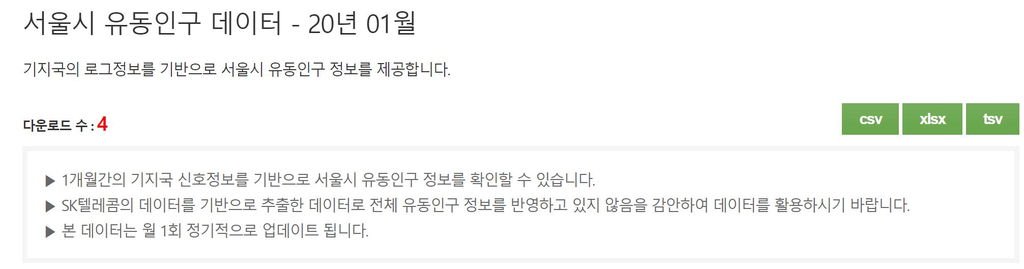

기지국에서 신호를 기반으로 측정한다고 하는데 그 이상은 파악이 힘들었다.

### 지역별

```r
Town_grouping <- year_19_pop_data_frame %>%
  group_by(Town) %>%
  summarize(Town_Pop = sum(Population)) %>%
  arrange(desc(Town_Pop))

Town_grouping %>%
  datatable()
```

|  | Town | Town_Pop |
| --- | --- | --- |
| 1 | 강남구 | 4336661530 |
| 2 | 송파구 | 3703750460 |
| 3 | 강서구 | 3121901040 |
| 4 | 서초구 | 3053351880 |
| 5 | 영등포구 | 2877141960 |
| 6 | 노원구 | 2807244390 |
| 7 | 관악구 | 2786364140 |
| 8 | 구로구 | 2539927610 |
| 9 | 마포구 | 2471448250 |
| 10 | 성북구 | 2419796520 |

[output cut: 15 more lines]

역시나 강남구, 송파구의 유동인구수가 가장 많이 나왔다. 두 지역에는 많은 식당들이 즐비하고 있고, 서점, 병원 등 편의시설이 많기로 유명하다. 그래서인지 타 지역에 비해 유독 많은 유동인구수가 측정된 것 같다.

# 시각화

앞서 각 조건별로 그룹화한 데이터를 가지고 시각화를 해보겠다.

### 1) 몇시에 유동인구 수가 가장 많을까?

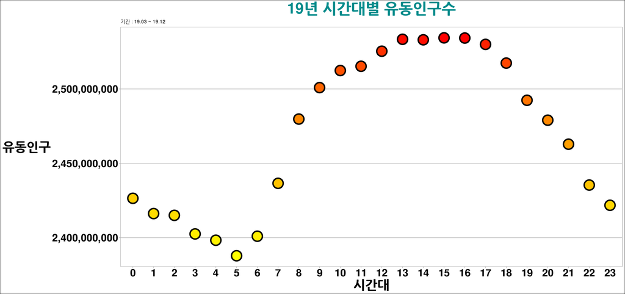

```r
# 시간별 시각화
# ggplot(Hour_grouping, aes(Hour, Hour_Pop)) +
#   geom_col(aes(fill = Sex)) +
#   scale_y_continuous(labels =  comma)+
#     ggtitle( "19년 시간대별 유동인구 그래프", subtitle = ("기간 : 19.03 ~ 19.12")) +
#   labs(x= "시간", y="유동인구 수")

#####
  ggplot(Hour_grouping, aes(Hour, Hour_Pop)) +
  # geom_col() +
 # geom_line(aes(size=5, color=Sex,  linetype = 1)) +
  # geom_line() +
  geom_point(size=8,alpha=9,stroke = 2,shape=21,aes(fill = Hour_Pop)) +
   scale_fill_gradient(low = 'yellow',
                      high = 'red') +
  guides(fill="none") +
  theme_calc() +
  # geom_text(aes(label=rownames(Hour_grouping))) +
  ggtitle("19년 시간대별 유동인구수", subtitle = ("기간 : 19.03 ~ 19.12")) +
  theme(plot.title = element_text(face="bold", hjust=0.5, vjust=1, size=30, color="#008B8B")) +
  xlab("시간대") +
  ylab("유동인구") +
  theme(axis.title.x=element_text(family="NanumGothic",
                                        face="bold",
                                        hjust=0.5,
                                        size=25,
                                        color="Black",
                                        angle=0),
   axis.title.y=element_text(family="NanumGothic",
                                        face="bold",
                                        vjust=0.5,
                                        size=25,
                                        color="Black",
                                        angle=0)) +
  scale_y_continuous(limits=c(min(Hour_grouping$Hour_Pop),
                              max(Hour_grouping$Hour_Pop)),
                              labels=scales::comma) +
  theme(axis.text.x = element_text(size=20, face ="bold")) +
  theme(axis.text.y = element_text(size=20, face ="bold"))
```

```r
# color = "#ff6600",
```

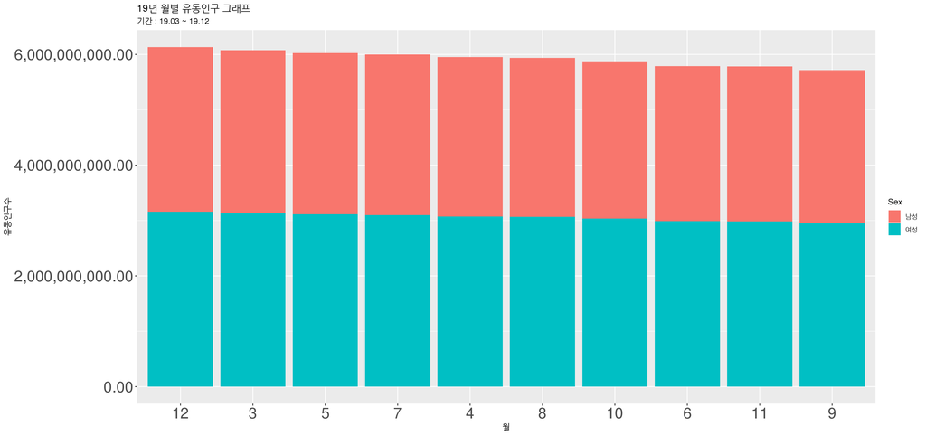

```r
# 월별, 성별 시각화
ggplot(Monnth_sex_grouping, aes(x=reorder(Month, -Mon_Wday_Pop), y=Mon_Wday_Pop)) +
  geom_col(aes(fill=Sex)) +
  #ggtitle( "19년 월별 유동인구 그래프", subtitle = ("기간 : 19.03 ~ 19.12")) +
  labs(title = "19년 월별 유동인구 그래프",x= "월", y="유동인구수", subtitle = "기간 : 19.03 ~ 19.12") +
  scale_y_continuous(labels =  comma) +
   theme(axis.text.x = element_text(size=20)) +
  theme(axis.text.y = element_text(size=20))
```

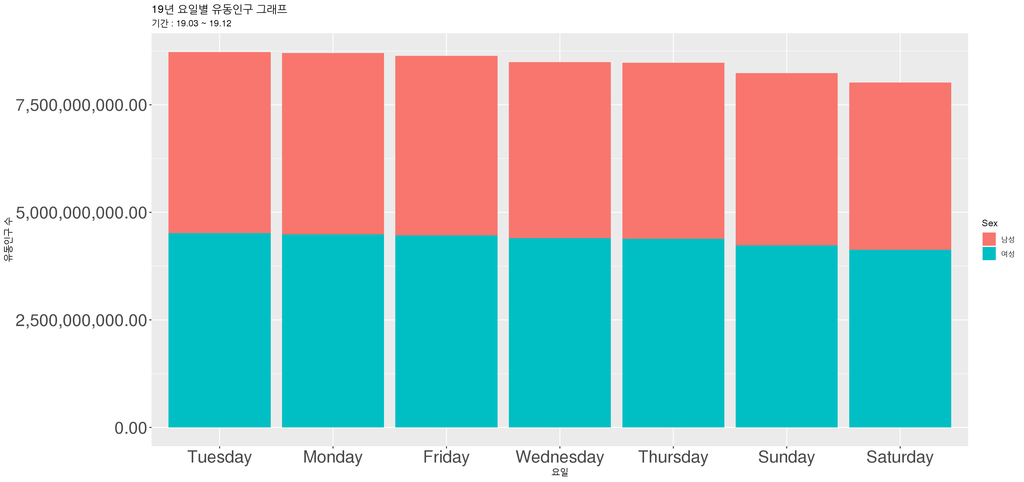

```r
# 요일별 시각화

# Wday_grouping <- year_19_pop_data_frame %>%
#   group_by(Wday) %>%
#   summarize(Wday_Pop = sum(Population)) %>%
#   arrange(desc(Wday_Pop)) %>% as.data.frame()
ggplot(Wday_grouping, aes(x= reorder(Wday, -Wday_Pop) , y=Wday_Pop)) +
      geom_col(aes( fill = Sex)) +
  scale_y_continuous(labels =  comma)+
    ggtitle( "19년 요일별 유동인구 그래프", subtitle = ("기간 : 19.03 ~ 19.12")) +
  labs(x= "요일", y="유동인구 수")  +
   theme(axis.text.x = element_text(size=20)) +
  theme(axis.text.y = element_text(size=20))
```

```r
   # scale_y_continuous(limits=c(min(Wday_grouping$Wday_Pop),
   #                            max(Wday_grouping$Wday_Pop)),
   #                            labels=scales::comma) +
```